# Estruturas de Dados em Python

*por Iuri Sônego Cardoso com auxílio de IA.*

As estruturas de dados são formas fundamentais de organizar e armazenar dados em um computador para que possam ser acessados e modificados de forma eficiente. Python oferece uma variedade de estruturas de dados, tanto nativas (built-in) quanto aquelas que podem ser implementadas ou importadas de módulos. Compreender e escolher a estrutura de dados apropriada para uma determinada tarefa é crucial para escrever código eficiente e elegante.

## 1 Estruturas de Dados Nativas em Python

Python já vem com algumas estruturas de dados poderosas e flexíveis que são amplamente utilizadas. Vamos explorar as principais:

### 1.1 Listas

Nós já usamos as Listas anteriormente neste curso. Quando trabalhamos com Vetores e Matrizes, foi dito que elas de fato não existem em Python.Nós utilizamos Listas para a implementação delas. As listas, assim como os vetores, são sequências ordenadas de itens. Isso significa que cada elemento em uma lista tem uma posição definida (índice), e essa ordem é mantida. Além de mutáveis (permitem alterações), diferentemente dos vetores em outras linguagens de programação (como C/C++, Java, C# etc), as listas são dinâmicas, o que significa que você pode adicionar ou remover elementos depois que a lista é criada.

**Uso:**

Para criar uma lista, você usa colchetes `[]` e separa os elementos por vírgulas.

```python
# Criando uma lista de números inteiros
numeros = [1, 2, 3, 4, 5]
print(f"Lista de números: {numeros}")

# Criando uma lista de strings
frutas = ["maçã", "banana", "laranja"]
print(f"Lista de frutas: {frutas}")

# Criando uma lista com diferentes tipos de dados
mista = [1, "olá", 3.14, True]
print(f"Lista mista: {mista}")
```

```
Lista de números: [1, 2, 3, 4, 5]
Lista de frutas: ['maçã', 'banana', 'laranja']
Lista mista: [1, 'olá', 3.14, True]
```

**Acessando Elementos:**

Você pode acessar elementos de uma lista usando seu índice (lembre-se que a indexação começa em 0).

```python
primeiro_numero = numeros[0]
print(f"O primeiro número é: {primeiro_numero}")

segunda_fruta = frutas[1]
print(f"A segunda fruta é: {segunda_fruta}")

# Índices negativos acessam elementos do final da lista
ultimo_elemento = mista[-1]
print(f"O último elemento da lista mista é: {ultimo_elemento}")
```

```
O primeiro número é: 1
A segunda fruta é: banana
O último elemento da lista mista é: True
```

**Operações Comuns:**

Python oferece várias operações em listas:

- **Adicionar elementos:** `.append()` (no final), `.insert(índice, elemento)` (em uma posição específica), `.extend(outra_lista)` (adiciona todos os elementos de outra lista).
- **Remover elementos:** `.remove(valor)` (remove a primeira ocorrência do valor), `.pop(índice)` (remove e retorna o elemento no índice; se nenhum índice for especificado, remove e retorna o último), `del lista[índice]` (remove o elemento em um índice específico).
- **Modificar elementos:** Basta atribuir um novo valor ao índice desejado (e.g., `numeros[0] = 10`).
- **Verificar a existência de um elemento:** `elemento in lista`.
- **Obter o tamanho da lista:** `len(lista)`.
- **Fatiamento (Slicing):** Permite acessar uma subseção da lista (e.g., `numeros[1:4]`).

```python
# Adicionando elementos
frutas.append("uva")
print(f"Lista de frutas após append: {frutas}")

frutas.insert(1, "morango")
print(f"Lista de frutas após insert: {frutas}")

outras_frutas = ["manga", "abacaxi"]
frutas.extend(outras_frutas)
print(f"Lista de frutas após extend: {frutas}")

# Removendo elementos
frutas.remove("banana")
print(f"Lista de frutas após remove: {frutas}")

elemento_removido = frutas.pop(2)
print(f"Lista de frutas após pop: {frutas}, elemento removido: {elemento_removido}")

del frutas[0]
print(f"Lista de frutas após del: {frutas}")

# Modificando um elemento
numeros[0] = 10
print(f"Lista de números modificada: {numeros}")

# Verificando existência
tem_uva = "uva" in frutas
print(f"'uva' está na lista de frutas? {tem_uva}")

# Tamanho da lista
tamanho_frutas = len(frutas)
print(f"O tamanho da lista de frutas é: {tamanho_frutas}")

# Fatiamento
sublista_numeros = numeros[1:4]
print(f"Sublista de números (índices 1 a 3): {sublista_numeros}")
```

```
Lista de frutas após append: ['maçã', 'banana', 'laranja', 'uva']
Lista de frutas após insert: ['maçã', 'morango', 'banana', 'laranja', 'uva']
Lista de frutas após extend: ['maçã', 'morango', 'banana', 'laranja', 'uva', 'manga', 'abacaxi']
Lista de frutas após remove: ['maçã', 'morango', 'laranja', 'uva', 'manga', 'abacaxi']
Lista de frutas após pop: ['maçã', 'morango', 'uva', 'manga', 'abacaxi'], elemento removido: laranja
Lista de frutas após del: ['morango', 'uva', 'manga', 'abacaxi']
Lista de números modificada: [10, 2, 3, 4, 5]
'uva' está na lista de frutas? True
O tamanho da lista de frutas é: 4
Sublista de números (índices 1 a 3): [2, 3, 4]
```

### 1.1.1 Deque, Uma Outra Forma de Lista

O módulo `collections` em Python oferece o `deque` (double-ended queue), que é uma generalização de pilhas e filas (vista adiante). Este tipo de estrutura de dados suporta adições e remoções eficientes de ambos os lados quando comparados com listas. Em termos de funcionalidade, eles se assemelham a listas, mas oferecem melhor desempenho para operações de adicionar e remover elementos no início ou no final da sequência.

**Comparação entre Deque e Lista:**

Listas em Python são implementadas em baixo nível (em C) como vetores dinâmicos. Isso significa que são vetores estáticos que necessitam ser realocados toda vez que é necessário aumentar o seu tamanho devido a inserção de um elemento novo. Além disto, sempre que um elemento é inserido no começo ou no meio do vetor, todos os valores existentes a partir daquela posição precisam ser copiados para as posições seguintes, consumindo tempo de processamento. Similarmente, de forma inversa, a remoção de um elemento que não é o último implica a cópia dos elementos posteriores, cada um, para uma posição imediatamente anterior.

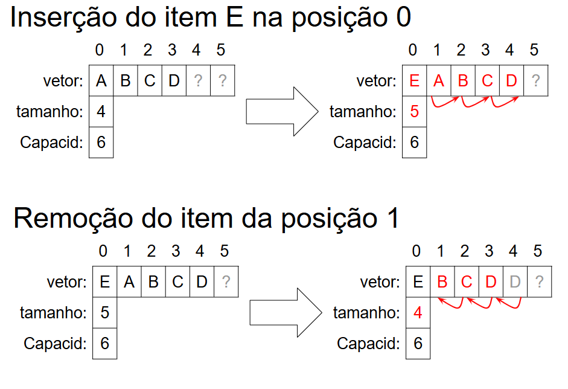

Deques são implementadas em baixo nível como listas duplamente encadeadas, em que os elementos não estão armazenados em vetores, mas sim em nós conectados por referências (ponteiros em Linguagem C). Isto significa que a inserção de um elemento no início ou no meio não necessita deslocar os demais. Basta inserir um novo nó, conectar este com os imediatamentes anterior e posterior. Na remoção, basta remover o nó e conectar os nós vizinhos entre eles.

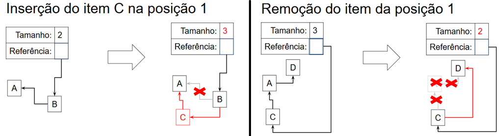

**Uso:**

Para usar `deque`, você precisa importá-lo do módulo `collections`.

```python
from collections import deque

# Criando um deque
fila_dupla = deque(["elemento1", "elemento2", "elemento3"])
print(f"Deque inicial: {fila_dupla}")

# Adicionando elementos
fila_dupla.append("elemento4")  # Adiciona ao final
fila_dupla.appendleft("elemento0") # Adiciona ao início
print(f"Deque após adicionar elementos: {fila_dupla}")

# Removendo elementos
elemento_direita = fila_dupla.pop()   # Remove e retorna o elemento da direita
elemento_esquerda = fila_dupla.popleft() # Remove e retorna o elemento da esquerda
print(f"Deque após remover elementos: {fila_dupla}, removido da direita: {elemento_direita}, removido da esquerda: {elemento_esquerda}")
```

```
Deque inicial: deque(['elemento1', 'elemento2', 'elemento3'])
Deque após adicionar elementos: deque(['elemento0', 'elemento1', 'elemento2', 'elemento3', 'elemento4'])
Deque após remover elementos: deque(['elemento1', 'elemento2', 'elemento3']), removido da direita: elemento4, removido da esquerda: elemento0
```

**Quando usar Deque?**

O `deque` é particularmente útil quando você precisa de uma estrutura de dados semelhante a uma lista, mas com a necessidade de realizar inserções e exclusões eficientes em ambas as extremidades. Isso o torna uma boa escolha para implementar filas (onde você adiciona em uma extremidade e remove da outra) e pilhas (onde você adiciona e remove da mesma extremidade).

### 1.2 Tuplas

As tuplas são semelhantes às listas, mas são **imutáveis**. Uma vez que uma tupla é criada, seus elementos não podem ser modificados, adicionados ou removidos. As tuplas são definidas usando parênteses `()`.

**Implementação:**

```python
# Criando uma tupla
ponto = (10, 20)
cores = ("vermelho", "verde", "azul")
tupla_mista = (1, "texto", 3.14)
tupla_de_um_elemento = (5,) # A vírgula é importante para definir uma tupla de um elemento

print(f"Tupla ponto: {ponto}")
print(f"Tupla de cores: {cores}")
print(f"Tupla mista: {tupla_mista}")
print(f"Tupla de um elemento: {tupla_de_um_elemento}")
```

```
Tupla ponto: (10, 20)
Tupla de cores: ('vermelho', 'verde', 'azul')
Tupla mista: (1, 'texto', 3.14)
Tupla de um elemento: (5,)
```

**Acessando Elementos:**

Assim como nas listas, você pode acessar elementos de uma tupla usando seus índices.

```python
x = ponto[0]
y = ponto[1]
print(f"Coordenadas do ponto: x={x}, y={y}")

primeira_cor = cores[0]
print(f"A primeira cor é: {primeira_cor}")

# linha abaixo resulta em erro: não é possível atribuir novo valor
# cores[0] = "marrom"
```

```
Coordenadas do ponto: x=10, y=20
A primeira cor é: vermelho
```

**Por que usar Tuplas?**

- **Imutabilidade:** Garante que os dados permaneçam constantes ao longo do programa. Isso pode ser útil para representar valores fixos, como coordenadas, dias da semana, etc.
- **Desempenho:** Em algumas operações, as tuplas podem ser ligeiramente mais rápidas que as listas devido à sua natureza estática.
- **Chaves de Dicionários:** Tuplas podem ser usadas como chaves em dicionários (já que são imutáveis), enquanto listas não podem.
- **Retorno Múltiplo de Funções:** Funções em Python frequentemente retornam múltiplos valores como uma tupla.

### 1.3 Dicionários

Os dicionários são coleções não ordenadas de pares chave-valor. Cada chave em um dicionário deve ser imutável e única, e é usada para acessar o valor correspondente. Os dicionários são mutáveis e são definidos usando chaves `{}`.

**Implementação:**

```python
# Criando um dicionário
pessoa = {
    "nome": "Ana",
    "idade": 30,
    "cidade": "São Paulo"
  }
print(f"Dicionário pessoa: {pessoa}")

# Acessando valores usando chaves
nome = pessoa["nome"]
idade = pessoa["idade"]
print(f"Nome: {nome}, Idade: {idade}")

# Adicionando ou modificando pares chave-valor
pessoa["profissão"] = "Engenheira"
print(f"Dicionário pessoa após adicionar profissão: {pessoa}")

pessoa["idade"] = 31
print(f"Dicionário pessoa após modificar idade: {pessoa}")
```

```
Dicionário pessoa: {'nome': 'Ana', 'idade': 30, 'cidade': 'São Paulo'}
Nome: Ana, Idade: 30
Dicionário pessoa após adicionar profissão: {'nome': 'Ana', 'idade': 30, 'cidade': 'São Paulo', 'profissão': 'Engenheira'}
Dicionário pessoa após modificar idade: {'nome': 'Ana', 'idade': 31, 'cidade': 'São Paulo', 'profissão': 'Engenheira'}
```

**Operações Comuns:**

- **Acessar valores:** `dicionario[chave]` (se a chave não existir, levanta um `KeyError`), `.get(chave, valor_padrao)` (retorna o valor da chave ou um valor padrão se a chave não existir).
- **Adicionar/modificar pares:** `dicionario[nova_chave] = novo_valor`.
- **Remover pares:** `del dicionario[chave]` (levanta `KeyError` se a chave não existir), `.pop(chave, valor_padrao)` (remove e retorna o valor da chave; se a chave não existir, retorna o valor padrão ou levanta `KeyError` se nenhum padrão for fornecido), `.popitem()` (remove e retorna um par chave-valor arbitrário - útil para remover itens em ordem LIFO).
- **Verificar a existência de uma chave:** `chave in dicionario`.
- **Obter todas as chaves:** `dicionario.keys()` (retorna uma view).
- **Obter todos os valores:** `dicionario.values()` (retorna uma view).
- **Obter todos os pares chave-valor:** `dicionario.items()` (retorna uma view de tuplas).
- **Atualizar com outro dicionário:** `.update(outro_dicionario)` (adiciona ou atualiza pares chave-valor).

```python
# Acessando valores
cidade = pessoa.get("cidade")
print(f"Cidade: {cidade}")

pais = pessoa.get("pais", "Brasil") # Chave não existe, retorna o valor padrão
print(f"País: {pais}")

# Removendo pares
profissao = pessoa.pop("profissão")
print(f"Dicionário após pop: {pessoa}, profissão removida: {profissao}")

del pessoa["cidade"]
print(f"Dicionário após del: {pessoa}")

# Verificando existência de chave
tem_nome = "nome" in pessoa
print(f"'nome' está no dicionário? {tem_nome}")

# Iterando sobre o dicionário
print("\nIterando sobre as chaves:")
for chave in pessoa.keys():
    print(chave)

print("\nIterando sobre os valores:")
for valor in pessoa.values():
    print(valor)

print("\nIterando sobre os itens (chave-valor):")
for chave, valor in pessoa.items():
    print(f"{chave}: {valor}")
```

```
Cidade: São Paulo
País: Brasil
Dicionário após pop: {'nome': 'Ana', 'idade': 31, 'cidade': 'São Paulo'}, profissão removida: Engenheira
Dicionário após del: {'nome': 'Ana', 'idade': 31}
'nome' está no dicionário? True

Iterando sobre as chaves:
nome
idade

Iterando sobre os valores:
Ana
31

Iterando sobre os itens (chave-valor):
nome: Ana
idade: 31
```

### 1.4 Conjuntos

Conjuntos são coleções não ordenadas de elementos únicos. Isso significa que um conjunto não pode conter duplicatas. Os conjuntos são mutáveis e são definidos usando chaves `{}` ou a função `set()`.

**Implementação:**

```python
# Criando um conjunto
numeros_unicos = {1, 2, 3, 4, 5}
print(f"Conjunto de números únicos: {numeros_unicos}")

frutas_set = set(["maçã", "banana", "laranja", "maçã"]) # Duplicatas são removidas
print(f"Conjunto de frutas: {frutas_set}")
```

[output not shown]

**Operações Comuns:**

Conjuntos suportam operações matemáticas de conjuntos:

- **Adicionar elemento:** `.add(elemento)`.
- **Remover elemento:** `.remove(elemento)` (levanta `KeyError` se o elemento não existir), `.discard(elemento)` (remove o elemento se ele existir, sem levantar erro).
- **União:** `conjunto1 | conjunto2` ou `conjunto1.union(conjunto2)`.
- **Interseção:** `conjunto1 & conjunto2` ou `conjunto1.intersection(conjunto2)`.
- **Diferença:** `conjunto1 - conjunto2` ou `conjunto1.difference(conjunto2)` (elementos em `conjunto1` que não estão em `conjunto2`).
- **Diferença Simétrica:** `conjunto1 ^ conjunto2` ou `conjunto1.symmetric_difference(conjunto2)` (elementos que estão em um dos conjuntos, mas não em ambos).
- **Verificar subconjunto:** `conjunto1.issubset(conjunto2)`.
- **Verificar superconjunto:** `conjunto1.issuperset(conjunto2)`.
- **Verificar disjunção:** `conjunto1.isdisjoint(conjunto2)` (se não têm elementos em comum).

```python
# Adicionando e removendo elementos
numeros_unicos.add(6)
print(f"Conjunto após adicionar: {numeros_unicos}")

numeros_unicos.remove(3)
print(f"Conjunto após remover: {numeros_unicos}")

frutas_set.discard("abacaxi") # Não existe, mas não levanta erro
print(f"Conjunto de frutas após discard: {frutas_set}")

# Operações de conjuntos
conjunto_a = {1, 2, 3, 4}
conjunto_b = {3, 4, 5, 6}

uniao = conjunto_a | conjunto_b
print(f"União: {uniao}")

intersecao = conjunto_a & conjunto_b
print(f"Interseção: {intersecao}")

diferenca_ab = conjunto_a - conjunto_b
print(f"Diferença (A - B): {diferenca_ab}")

diferenca_simetrica = conjunto_a ^ conjunto_b
print(f"Diferença Simétrica: {diferenca_simetrica}")

# Verificações
eh_subconjunto = {1, 2}.issubset(conjunto_a)
print(f"{{1, 2}} é subconjunto de {conjunto_a}? {eh_subconjunto}")
```

[output not shown]

## 2 Estruturas de Dados Derivadas

Além das estruturas de dados nativas, podemos usar as estruturas existentes para implementar outras, como pilhas e filas.

### 2.1 Pilhas

Uma pilha (stack) é uma estrutura de dados que segue o princípio LIFO (Last-In, First-Out), onde o último elemento adicionado é o primeiro a ser removido. Podemos implementar uma pilha de forma simples utilizando listas em Python.

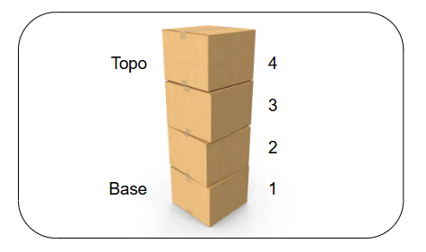

Fonte da Imagem: Internet

**Implementação usando Lista:**

Para implementar uma pilha com uma lista, as operações de "empilhar" (adicionar um elemento ao topo) e "desempilhar" (remover o elemento do topo) correspondem, respectivamente, aos métodos `.append()` e `.pop()` da lista. O "topo" da pilha será sempre o último elemento da lista.

```python
# Criando uma pilha vazia
pilha_lista = []

# Empilhando elementos
pilha_lista.append(10)
pilha_lista.append(20)
pilha_lista.append(30)

print(f"Pilha (lista) inicial: {pilha_lista}")

# Verificando se a pilha está vazia
esta_vazia = not pilha_lista
print(f"A pilha está vazia? {esta_vazia}")

# Verificando o topo da pilha
if pilha_lista:
    topo = pilha_lista[-1]
    print(f"Topo da pilha: {topo}")
else:
    print("A pilha está vazia, não há topo.")

# Desempilhando um elemento
elemento_removido = pilha_lista.pop() if pilha_lista else None
print(f"Elemento desempilhado: {elemento_removido}")
print(f"Pilha (lista) após desempilhar: {pilha_lista}")

# Tamanho da pilha
tamanho = len(pilha_lista)
print(f"Tamanho da pilha: {tamanho}")

# Desempilhando toda a pilha
print("Desempilhando todos os elementos:")
while pilha_lista:
  elemento_removido = pilha_lista.pop()
  print(f" {elemento_removido}")
print(f"Tamanho da pilha: {len(pilha_lista)}")
```

```
Pilha (lista) inicial: [10, 20, 30]
A pilha está vazia? False
Topo da pilha: 30
Elemento desempilhado: 30
Pilha (lista) após desempilhar: [10, 20]
Tamanho da pilha: 2
Desempilhando todos os elementos:
 20
 10
Tamanho da pilha: 0
```

**Implementação usando `deque`:**

O `deque` do módulo `collections` também é uma excelente opção para implementar pilhas, oferecendo a mesma eficiência para as operações de adicionar e remover do final.

```python
from collections import deque

# Criando uma pilha vazia usando deque
pilha_deque = deque()

# Empilhando elementos
pilha_deque.append(10)
pilha_deque.append(20)
pilha_deque.append(30)

print(f"Pilha (deque) inicial: {pilha_deque}")

# Verificando se a pilha está vazia
esta_vazia_deque = not pilha_deque
print(f"A pilha (deque) está vazia? {esta_vazia_deque}")

# Verificando o topo da pilha
if pilha_deque:
    topo_deque = pilha_deque[-1]
    print(f"Topo da pilha (deque): {topo_deque}")
else:
    print("A pilha (deque) está vazia, não há topo.")

# Desempilhando um elemento
elemento_removido_deque = pilha_deque.pop() if pilha_deque else None
print(f"Elemento desempilhado (deque): {elemento_removido_deque}")
print(f"Pilha (deque) após desempilhar: {pilha_deque}")

# Tamanho da pilha
tamanho_deque = len(pilha_deque)
print(f"Tamanho da pilha (deque): {tamanho_deque}")

# Desempilhando toda a pilha
print("Desempilhando todos os elementos:")
while pilha_deque:
  elemento_removido_deque = pilha_deque.pop()
  print(f" {elemento_removido_deque}")
print(f"Tamanho da pilha (deque): {len(pilha_deque)}")
```

```
Pilha (deque) inicial: deque([10, 20, 30])
A pilha (deque) está vazia? False
Topo da pilha (deque): 30
Elemento desempilhado (deque): 30
Pilha (deque) após desempilhar: deque([10, 20])
Tamanho da pilha (deque): 2
Desempilhando todos os elementos:
 20
 10
Tamanho da pilha (deque): 0
```

**Observação:** Embora listas possam ser usadas para implementar pilhas, o `deque` é geralmente mais eficiente para operações de adicionar e remover do final em cenários onde o desempenho é crítico, especialmente com um grande número de operações.

### 2.2 Filas

Uma fila (queue) é uma estrutura de dados que segue o princípio FIFO (First-In, First-Out), onde o primeiro elemento adicionado é o primeiro a ser removido.

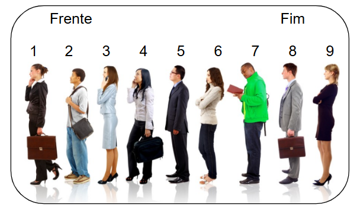

Fonte da imagem: Internet.

**Implementação usando Lista (Ineficiente):**

Podemos tentar implementar uma fila usando uma lista, onde a adição de elementos ocorre no final (`append()`) e a remoção ocorre no início. No entanto, remover o primeiro elemento de uma lista (`pop(0)`) é uma operação ineficiente, pois todos os outros elementos precisam ser deslocados, resultando em uma complexidade de tempo O(n), onde n é o número de elementos na lista.

```python
# Criando uma fila vazia (usando lista - INEFICIENTE para remoção)
fila_lista = []

# Enfileirando elementos
fila_lista.append("primeiro")
fila_lista.append("segundo")
fila_lista.append("terceiro")

print(f"Fila (lista) inicial: {fila_lista}")

# Verificando se a fila está vazia
esta_vazia_fila_lista = not fila_lista
print(f"A fila (lista) está vazia? {esta_vazia_fila_lista}")

# Desenfileirando um elemento (ineficiente)
elemento_removido_fila_lista = fila_lista.pop(0) if fila_lista else None
print(f"Elemento desenfileirado (lista): {elemento_removido_fila_lista}")
print(f"Fila (lista) após desenfileirar: {fila_lista}")

# Verificando o primeiro elemento da fila
if fila_lista:
    primeiro_elemento_fila_lista = fila_lista[0]
    print(f"Primeiro elemento da fila (lista): {primeiro_elemento_fila_lista}")
else:
    print("A fila (lista) está vazia.")

# Tamanho da fila
tamanho_fila_lista = len(fila_lista)
print(f"Tamanho da fila (lista): {tamanho_fila_lista}")

# desenfileirando todos
print("\nDesenfileirando todos:")
while fila_lista:
  e = fila_lista.pop(0)
  print(e)
print(f"Tamanho da fila (lista): {len(fila_lista)}")
```

[output not shown]

**Implementação usando `deque` (Eficiente):**

O `deque` do módulo `collections` é a estrutura ideal para implementar filas de forma eficiente. Podemos usar `append()` para adicionar elementos ao final (enfileirar) e `popleft()` para remover elementos do início (desenfileirar), ambas com complexidade de tempo O(1).

```python
from collections import deque

# Criando uma fila vazia usando deque
fila_deque = deque()

# Enfileirando elementos
fila_deque.append("primeiro")
fila_deque.append("segundo")
fila_deque.append("terceiro")

print(f"Fila (deque) inicial: {fila_deque}")

# Verificando se a fila está vazia
esta_vazia_fila_deque = not fila_deque
print(f"A fila (deque) está vazia? {esta_vazia_fila_deque}")

# Desenfileirando um elemento (eficiente)
elemento_removido_fila_deque = fila_deque.popleft() if fila_deque else None
print(f"Elemento desenfileirado (deque): {elemento_removido_fila_deque}")
print(f"Fila (deque) após desenfileirar: {fila_deque}")

# Verificando o primeiro elemento da fila
if fila_deque:
    primeiro_elemento_fila_deque = fila_deque[0]
    print(f"Primeiro elemento da fila (deque): {primeiro_elemento_fila_deque}")
else:
    print("A fila (deque) está vazia.")

# Tamanho da fila
tamanho_fila_deque = len(fila_deque)
print(f"Tamanho da fila (deque): {tamanho_fila_deque}")

# desenfileirando todos
print("\nDesenfileirando todos:")
while fila_deque:
  e = fila_deque.popleft()
  print(e)
print(f"Tamanho da fila (lista): {len(fila_deque)}")
```

[output not shown]